# Activity monitoring data analysis

Yilin

February 11, 2016

The raw data is collected by a personal activity monitoring device. This device collects data at 5 minute intervals through out the day. The data consists of two months of data from an anonymous individual collected during the months of Octorber and November,2012 and include the number of steps taken in t minute intervals each day.

Step1: Read the data

```r
rawdata<-read.csv(unz("activity.zip","activity.csv"), sep=",")
```

Step2: histogram showing the total number of steps taken each day

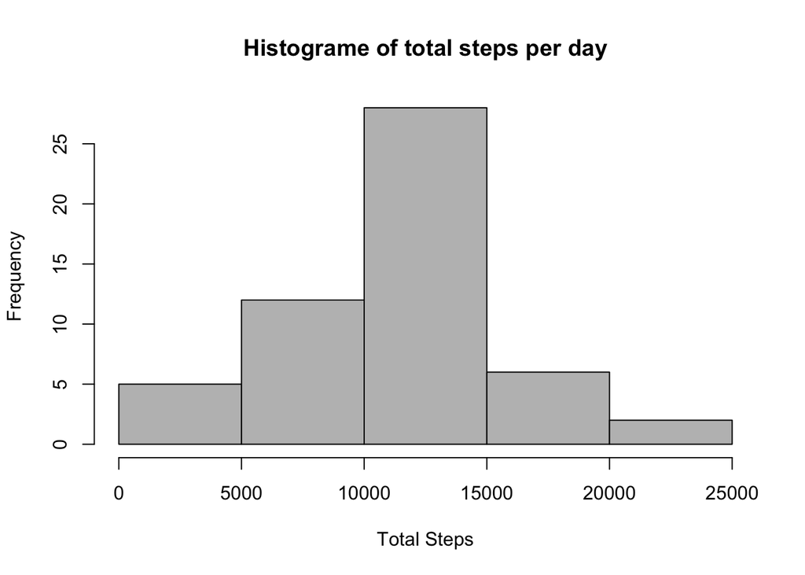

```r
sumsteps<-aggregate(steps~date,data=rawdata,sum,na.action=na.omit)
hist(sumsteps[,2],main="Histograme of total steps per day",xlab="Total Steps",col="grey")
```

```r
dev.copy(png,width=480,height=480,filename="Histograme of total steps per day.png")
dev.off()
```

Step3: Mean and median number of steps taken each day

```r
meansteps<-aggregate(steps~date,data=rawdata,mean,na.action=na.omit)
mediansteps<-aggregate(steps~date,data=rawdata,median,na.action=na.omit)
head(meansteps)
```

```
##         date    steps
## 1 2012-10-02  0.43750
## 2 2012-10-03 39.41667
## 3 2012-10-04 42.06944
## 4 2012-10-05 46.15972
## 5 2012-10-06 53.54167
## 6 2012-10-07 38.24653
```

```r
head(mediansteps)
```

```
##         date steps
## 1 2012-10-02     0
## 2 2012-10-03     0
## 3 2012-10-04     0
## 4 2012-10-05     0
## 5 2012-10-06     0
## 6 2012-10-07     0
```

```r
range(meansteps$steps)
```

```
## [1]  0.1423611 73.5902778
```

Step4: Plot time series plot of the average number of steps taken

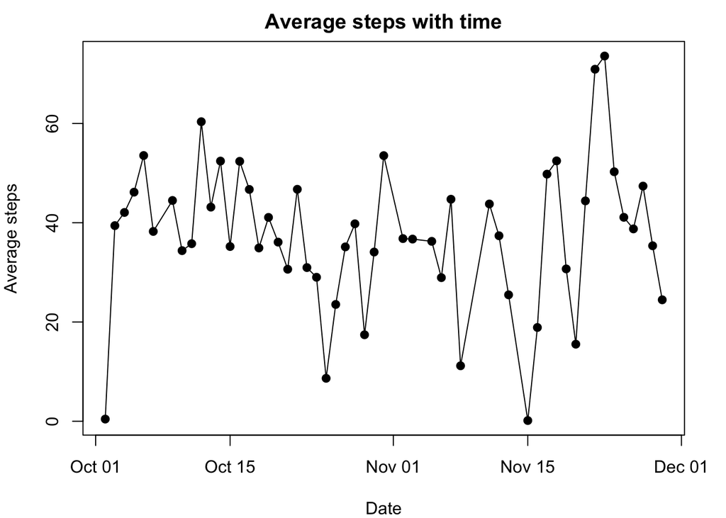

```r
par(mfrow=c(1,1), mar=c(4,4,2,2))
meansteps$date<-as.Date(meansteps$date)
plot(meansteps,type="o",pch=19,main="Average steps with time",xlab="Date",ylab="Average steps")
```

```r
dev.copy(png,width=480,height=480,filename="Time series plot of average number of steps taken.png")
dev.off()
```

Stpe5:Find out the 5-minute interval that, on average,contains the maximum number of steps

```r
library(dplyr)
meansteps_interval<-aggregate(steps~interval,data=rawdata,mean,na.action=na.omit)
meansteps_interval<-arrange(meansteps_interval,steps)
max<-meansteps_interval[length(meansteps_interval$steps),]
max
```

```
##     interval    steps
## 288      835 206.1698
```

Step6:clean the data by substituting “NA”" by the mean of their corresponding interval

```r
library(reshape2)
rawdata_t<-melt(rawdata,id=c("interval","date"),na.rm=TRUE)
mean_interval<-dcast(rawdata_t,variable~interval,mean)
mean_interval<-melt(mean_interval,variable.name="interval",value.name="steps")
cleandata<-merge(rawdata,mean_interval[,-1],by="interval",all=TRUE,sort=TRUE)
cleandata$steps.x[is.na(cleandata$steps.x)]<-cleandata$steps.y[is.na(cleandata$steps.x)]
cleandata<-arrange(cleandata[,-4],date,interval,steps.x)
cleandata<-cleandata[,c(3,1,2)]
```

Step7: Plot Histograme of the total number of steps taken each day after missing values are imputed

```r
tsteps<-dcast(melt(cleandata,id=c("interval","date")),variable~date,sum)
tsteps<-melt(tsteps,variable.name="date",value.name="total_steps")
```

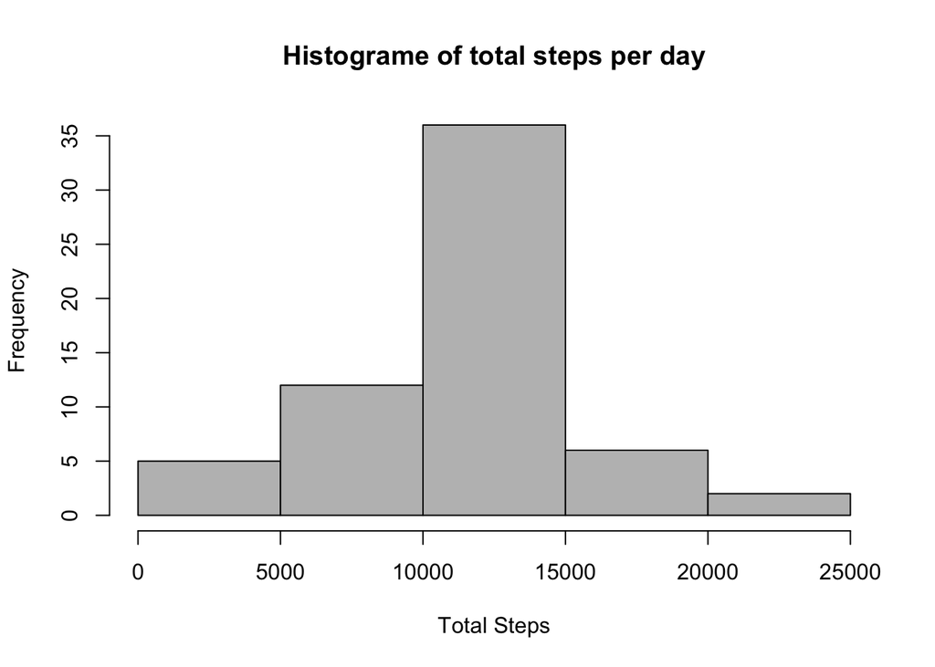

```r
hist(tsteps$total_steps,main="Histograme of total steps per day",xlab="Total Steps",col="grey")
```

```r
dev.copy(png,width=480,height=480,filename="Histograme of total steps per day_clean data.png")
dev.off()
```

Step8: Panel plot comparing the average number of steps taken per 5-minute interval across weekdays and weekends

```r
library(lubridate)
```

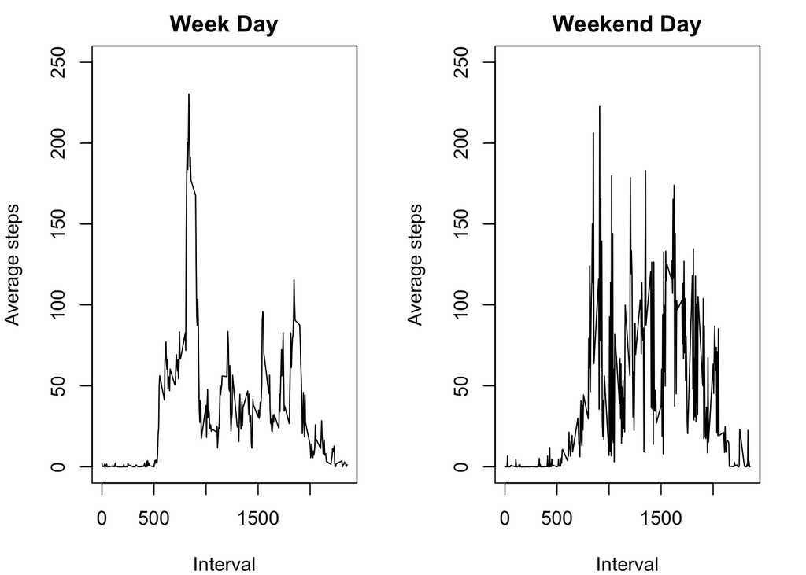

```r
cleandata<-mutate(cleandata,week=weekdays(ymd(date)))
weekend_data<-cleandata[cleandata$week==c("Saturday","Sunday"),]
weekday_data<-cleandata[cleandata$week!=c("Saturday"),]
weekday_data<-weekday_data[weekday_data$week!=c("Sunday"),]
asteps_weekday<-aggregate(steps.x~interval,data=weekday_data,mean)
asteps_weekend<-aggregate(steps.x~interval,data=weekend_data,mean)
par(mfrow=c(1,2),mar=c(4,4,2,2))
plot(asteps_weekday,type="l",main="Week Day",xlab="Interval",ylab="Average steps",ylim=c(0,250))
plot(asteps_weekend,type="l",main="Weekend Day",xlab="Interval",ylab="Average steps",ylim=c(0,250))
```

```r
dev.copy(png,width=480,height=480,filename="Comparing weekdays and weekends.png")
dev.off()
```